# Prediction of Exercise Movement using Accelerometer Data

Monday, June 15, 2015

**Introduction**

The goal of this analysis is to build a predictive model using data from accelerometers on the belt, forearm, arm, and dumbell of 6 participants who were asked to perform barbell lifts correctly and incorrectly in 5 different ways. The model predicts the manner in which the exercise was performed.

For more information about this dataset, please see the following website and reference:

http://groupware.les.inf.puc-rio.br/har

Velloso, E.; Bulling, A.; Gellersen, H.; Ugulino, W.; Fuks, H. Qualitative Activity Recognition of Weight Lifting Exercises. Proceedings of 4th International Conference in Cooperation with SIGCHI (Augmented Human ’13) . Stuttgart, Germany: ACM SIGCHI, 2013.

**Preparation of Dataset**

The training dataset was downloaded from https://d396qusza40orc.cloudfront.net/predmachlearn/pml-training.csv into the local directory used for analysis.

First we load required libraries and set the seed in order to ensure reproducibility.

Next we read the dataset, converting all potential predictors to numeric type (with blanks converted to NAs).

The outcome (class) is the ‘classe’ column, which we make into a factor.

```r
ds = read.csv("pml-training.csv", stringsAsFactors = FALSE)

for (i in 8:(ncol(ds) - 1))
{
  # Convert predictors to numeric (blanks as NAs)
  if (!is.numeric(ds[, i]))  ds[, i] = as.numeric(ds[, i])
}

ds$classe = factor(ds$classe)
```

We split the dataset into training and test subsets, using 80% of the data for training.

We remove columns not to be used for prediction, since they are not accelerometer readings.

We also remove columns with near-zero variance.

```r
# Split dataset into training and testings sets
training = createDataPartition(y = ds$classe, p = 0.80, list = FALSE)

train = ds[training, ]
test = ds[-training, ]

# Columns not to be used for predictions
do.not.use = c("X",
               "user_name",
               "raw_timestamp_part_1",
               "raw_timestamp_part_2",
               "cvtd_timestamp",
               "new_window",
               "num_window")

# Don't use near-zero-variance columns for predictions either
near.zero = nearZeroVar(train)

ok = NULL
for (i in 1:ncol(train))
{
  if (is.numeric(train[, i]))
    if (!(colnames(train)[i] %in% c("classe", do.not.use, colnames(train)[near.zero])))
      ok = c(colnames(train)[i], ok)
}

train.ok = train[, c("classe", ok)]
test.ok = test[, c("classe", ok)]
```

We impute missing (NA) values using KNN.

```r
preObj = preProcess(train.ok[, -1], method="knnImpute")
train = data.frame(classe=train.ok$classe, predict(preObj, train.ok[, -1]))
test = data.frame(classe=test.ok$classe, predict(preObj, test.ok[, -1]))
```

**Analysis**

We build a Random Forest model using the training subset.

```r
# Create random forest, and use for predictions on test set

rf = randomForest(x=train[,-1], y=train$classe, importance = TRUE, ntree=200)
pp = predict(rf, newdata = test[, -1])
```

The out of sample error is estimated by the Random Forest’s OOB error rate.

Random Forest OOB error rate:

```
## [1] 0.009236257
```

A better estimate of out of sample error is obtained using the 20% of the dataset that was not used to build the model.

Test set error rate:

```
## [1] 0.008666837
```

Random Forest Error Rate Plot:

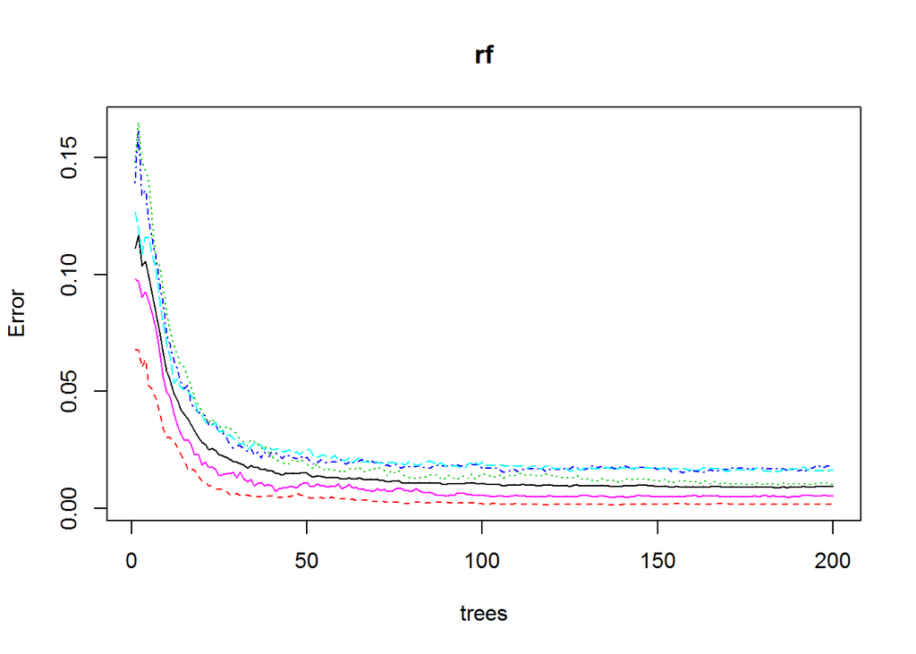

Random Forest Variable Importance (Top 10) Plot

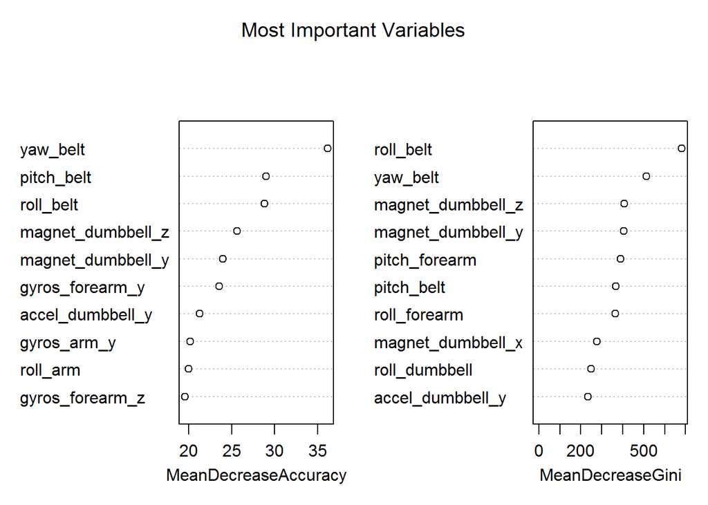

**Conclusion**

Using the accelerometer dataset, it appears possible to predict the manner of movement with approximately 99% accuracy. This model was developed using 80% of the dataset and tested on the remaining 20% to avoid overfitting. Additional work could be done to zero in on the most important predictors, and attempt to build a model with similar performance but fewer predictors.